# PCIT-CoS-Waitlist RCT Paper 1: DECA Total Protective Factors ASD

Nancy Briggs

24 May 2022

### DECA Total Protective Factors Adjusting for ASD

NOTE THE RESIDUALS FOR THIS OUTCOME ARE NOT GREAT AND A LOG TRANSFORM DOESNT HELP

#### Descriptives

| asdcase | group | time | n | mean | sd | median | min | max |
| --- | --- | --- | --- | --- | --- | --- | --- | --- |
| 0 | 1 | 1 | 24 | 38.21 | 11.05 | 34.0 | 28 | 64 |
| 0 | 1 | 2 | 19 | 36.74 | 10.39 | 33.0 | 28 | 63 |
| 0 | 1 | 3 | 14 | 32.86 | 4.19 | 34.0 | 28 | 39 |
| 0 | 2 | 1 | 24 | 38.54 | 12.13 | 35.0 | 28 | 64 |
| 0 | 2 | 2 | 11 | 35.36 | 10.58 | 33.0 | 28 | 63 |
| 0 | 2 | 3 | 5 | 31.80 | 3.77 | 32.0 | 28 | 36 |
| 0 | 3 | 1 | 25 | 40.04 | 10.68 | 37.0 | 28 | 67 |
| 0 | 3 | 2 | 22 | 32.23 | 4.93 | 30.0 | 28 | 43 |
| 0 | 3 | 3 | 0 | NaN | NA | NA | Inf | -Inf |
| 1 | 1 | 1 | 6 | 32.50 | 7.40 | 29.5 | 28 | 47 |
| 1 | 1 | 2 | 5 | 35.60 | 13.43 | 28.0 | 28 | 59 |
| 1 | 1 | 3 | 5 | 28.00 | 0.00 | 28.0 | 28 | 28 |
| 1 | 2 | 1 | 3 | 28.67 | 1.15 | 28.0 | 28 | 30 |
| 1 | 2 | 2 | 2 | 32.00 | 5.66 | 32.0 | 28 | 36 |
| 1 | 2 | 3 | 0 | NaN | NA | NA | Inf | -Inf |
| 1 | 3 | 1 | 5 | 32.20 | 4.27 | 32.0 | 28 | 37 |
| 1 | 3 | 2 | 4 | 28.00 | 0.00 | 28.0 | 28 | 28 |
| 1 | 3 | 3 | 0 | NaN | NA | NA | Inf | -Inf |

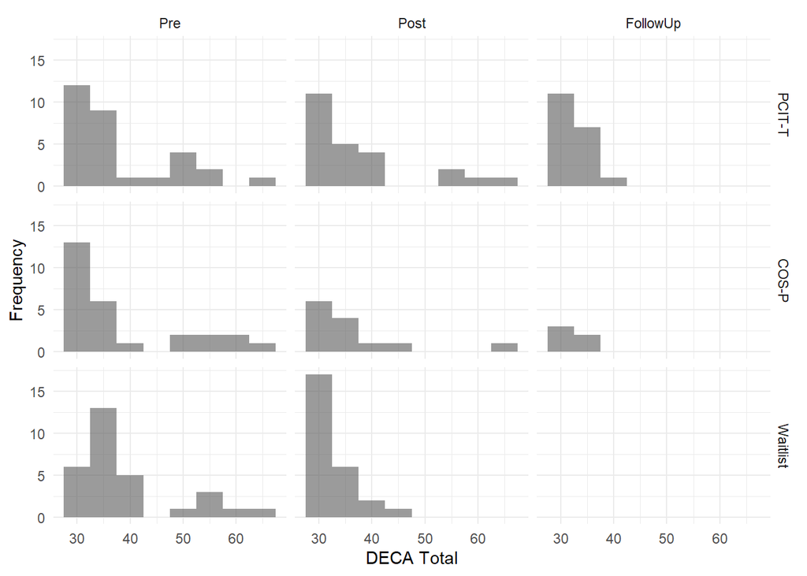

#### Model & Results

A linear mixed model with random effect for individual and fixed effects of group, time and the interaction was run. ASD status was then entered into the model as a main effect and then the 3-way interaction. Estimated marginal means were obtained, and contrasts specified to test Hypothesis 1 and Hypothesis 2.

```
## fixed-effect model matrix is rank deficient so dropping 1 column / coefficient
```

```
## fixed-effect model matrix is rank deficient so dropping 3 columns / coefficients
```

This is the ANOVA table for the model. p-values are likelihood ratio tests for adding the new term to the model just before. A p-value <0.05 indicates that adding that term results in better model fit. The most important p-value is the interaction p-value.

```
## refitting model(s) with ML (instead of REML)
```

[output not shown]

Model3, the model with Group*Time, adjusted by ASD will be the model I use for Estimated Means.

```r
summary(result3)
```

```
## Linear mixed model fit by REML. t-tests use Satterthwaite's method [
## lmerModLmerTest]
## Formula: outcome ~ asdcase + group * time + (1 | id)
##    Data: dat
##
## REML criterion at convergence: 1220.6
##
## Scaled residuals:
##     Min      1Q  Median      3Q     Max
## -1.2723 -0.6269 -0.1916  0.3351  2.9873
##
## Random effects:
##  Groups   Name        Variance Std.Dev.
##  id       (Intercept) 24.93    4.993
##  Residual             60.64    7.787
## Number of obs: 174, groups:  id, 88
##
## Fixed effects:
##               Estimate Std. Error        df t value Pr(>|t|)
## (Intercept)   38.16218    1.74467 143.12210  21.874   <2e-16 ***
## asdcase1      -5.47754    2.18795  70.83565  -2.504   0.0146 *
## group2        -0.05652    2.46000 148.29066  -0.023   0.9817
## group3         1.48408    2.38958 147.85023   0.621   0.5355
## time2         -0.83056    2.16685  90.73679  -0.383   0.7024
## time3         -5.64522    2.34865  95.51326  -2.404   0.0182 *
## group2:time2  -2.14900    3.52726 106.50953  -0.609   0.5437
## group3:time2  -6.07227    3.02328  89.16641  -2.009   0.0476 *
## group2:time3  -1.60095    4.72532 113.53620  -0.339   0.7354
## ---
## Signif. codes:  0 '***' 0.001 '**' 0.01 '*' 0.05 '.' 0.1 ' ' 1
##
## Correlation of Fixed Effects:
##             (Intr) asdcs1 group2 group3 time2  time3  grp2:2 grp3:2
## asdcase1    -0.251
## group2      -0.685  0.080
## group3      -0.692  0.031  0.488
## time2       -0.533 -0.006  0.379  0.390
## time3       -0.485 -0.034  0.347  0.359  0.426
## group2:tim2  0.332 -0.015 -0.500 -0.240 -0.614 -0.261
## group3:tim2  0.380  0.011 -0.271 -0.559 -0.717 -0.306  0.440
## group2:tim3  0.235  0.041 -0.364 -0.178 -0.212 -0.498  0.310  0.152
## fit warnings:
## fixed-effect model matrix is rank deficient so dropping 1 column / coefficient
```

#### Estimated Means & Change

Estimated means for each Treatment and Time (adjusted by ASD status) are presented. In addition, within-group change between time points is presented with 95% CIs.

##### Group mean difference at each timepoint

Effect sizes all calculated by the pooled T1 SD of the outcome. Adjusted p-value from Bonferroni correction.

Group Differences at Each Time Point

| Group Difference | Time | Mean | SE | t | p | adj p | Lower CL | Upper CL | Effect Size | Lower CL | Upper CL |
| --- | --- | --- | --- | --- | --- | --- | --- | --- | --- | --- | --- |
| 1 - 2 | 1 | 0.057 | 2.460 | 0.023 | 1.000 | 1.000 | -5.768 | 5.881 | 0.005 | -0.591 | 0.508 |
| 1 - 3 | 1 | -1.484 | 2.390 | -0.621 | 0.809 | 1.000 | -7.141 | 4.173 | -0.133 | -0.720 | 0.319 |
| 2 - 3 | 1 | -1.541 | 2.456 | -0.627 | 0.805 | 1.000 | -7.354 | 4.273 | -0.138 | -0.682 | 0.389 |
| 1 - 2 | 2 | 2.206 | 3.147 | 0.701 | 0.763 | 1.000 | -5.239 | 9.650 | 0.197 | -0.492 | 0.875 |
| 1 - 3 | 2 | 4.588 | 2.606 | 1.760 | 0.186 | 0.241 | -1.579 | 10.756 | 0.410 | -0.091 | 1.037 |
| 2 - 3 | 2 | 2.383 | 3.103 | 0.768 | 0.723 | 1.000 | -4.957 | 9.722 | 0.213 | -0.427 | 0.927 |
| 1 - 2 | 3 | 1.657 | 4.495 | 0.369 | 0.928 | 1.000 | -8.978 | 12.293 | 0.148 | -0.883 | 1.051 |
| 1 - 3 | 3 | NA | NA | NA | NA | NA | NA | NA | NA | NA | NA |
| 2 - 3 | 3 | NA | NA | NA | NA | NA | NA | NA | NA | NA | NA |

* Effect size scaled by pooled T1 SD  
† ES 95% Bootstrapped Percentile CI limits  
‡ If you want a positive ES (and it is calculated as negative), be sure to switch the signs and positions of the lower and upper CIs.

##### Change within each group

Within-Group Change and Effect Sizes

| Change | Group | Mean | SE | t | p | adj p | Lower CL | Upper CL | Effect Size | Lower CL | Upper CL |
| --- | --- | --- | --- | --- | --- | --- | --- | --- | --- | --- | --- |
| 1 - 2 | 1 | 0.831 | 2.170 | 0.383 | 0.923 | 1.000 | -4.337 | 5.999 | 0.074 | -0.340 | 0.587 |
| 1 - 3 | 1 | 5.645 | 2.355 | 2.397 | 0.048 | 0.055 | 0.040 | 11.250 | 0.505 | 0.113 | 1.137 |
| 2 - 3 | 1 | 4.815 | 2.427 | 1.984 | 0.122 | 0.151 | -0.968 | 10.597 | 0.430 | 0.008 | 1.020 |
| 1 - 2 | 2 | 2.980 | 2.797 | 1.065 | 0.538 | 0.867 | -3.659 | 9.618 | 0.266 | -0.264 | 0.962 |
| 1 - 3 | 2 | 7.246 | 4.130 | 1.754 | 0.189 | 0.246 | -2.553 | 17.045 | 0.648 | -0.100 | 1.636 |
| 2 - 3 | 2 | 4.267 | 4.328 | 0.986 | 0.587 | 0.979 | -6.020 | 14.554 | 0.381 | -0.435 | 1.323 |
| 1 - 2 | 3 | 6.903 | 2.110 | 3.271 | 0.004 | 0.005 | 1.875 | 11.931 | 0.617 | 0.286 | 1.205 |
| 1 - 3 | 3 | NA | NA | NA | NA | NA | NA | NA | NA | NA | NA |
| 2 - 3 | 3 | NA | NA | NA | NA | NA | NA | NA | NA | NA | NA |

* Effect size scaled by pooled T1 SD  
† ES 95% Bootstrapped Percentile CI limits  
‡ If you want a positive ES (and it is calculated as negative), be sure to switch the signs and positions of the lower and upper CIs.

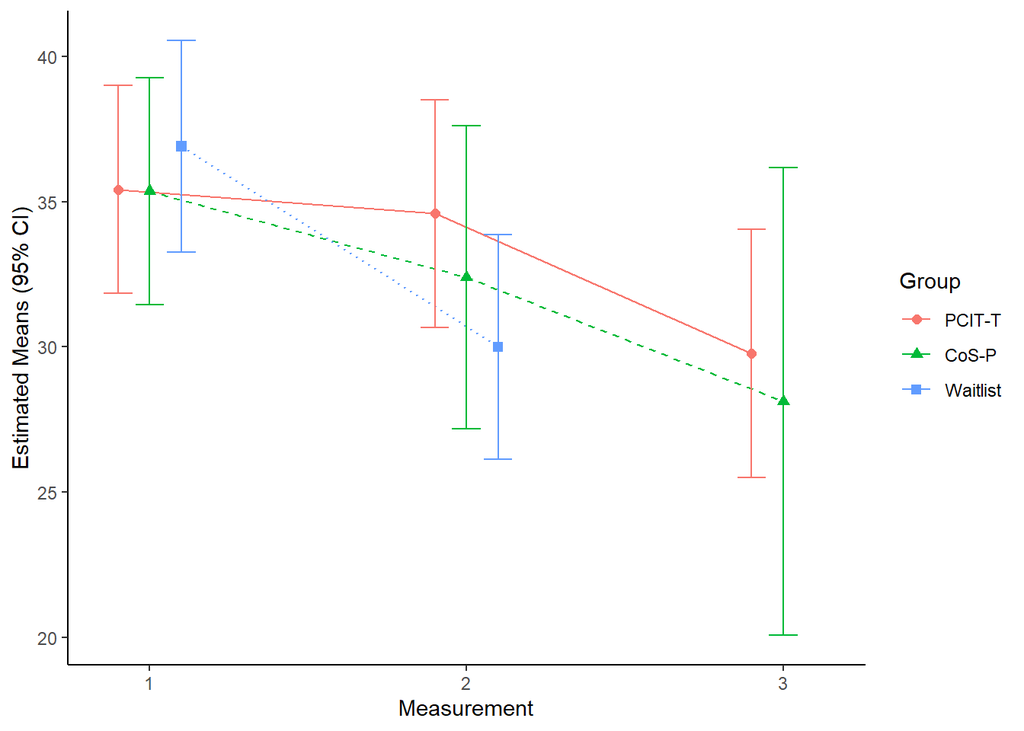

#### Hypothesis 1

We hypothesize that from baseline (‘T1’) to post-treatment/waitlist (‘T2’) there will be a gradient effect, whereby parent-child dyads who receive PCIT-T will show the greatest gains and parent-child dyads who receive no treatment will show the least gains. For the outcome, then, the null hypothesis is:

$H_0: \text {mean change}(\text{PCIT-T}) = \text {mean change}(\text{CoS-P}) = \text {mean change}(\text{Waitlist})$ $H_A: \text {mean change}(\text{PCIT-T}) > \text {mean change}(\text{CoS-P}) > \text {mean change}(\text{Waitlist})$

This is a joint hypothesis test.

First, confirming that the ordering of the means is as hypothesized:

```
## group = 1:
##  contrast estimate   SE    df t.ratio p.value
##  1 - 2       0.831 2.17  94.1   0.383  0.9225
##  1 - 3       5.645 2.36  98.8   2.397  0.0480
##  2 - 3       4.815 2.43  90.7   1.984  0.1220
##
## group = 2:
##  contrast estimate   SE    df t.ratio p.value
##  1 - 2       2.980 2.80 119.6   1.065  0.5375
##  1 - 3       7.246 4.13 122.8   1.754  0.1894
##  2 - 3       4.267 4.33 106.5   0.986  0.5874
##
## group = 3:
##  contrast estimate   SE    df t.ratio p.value
##  1 - 2       6.903 2.11  90.9   3.271  0.0043
##  1 - 3      nonEst   NA    NA      NA      NA
##  2 - 3      nonEst   NA    NA      NA      NA
##
## Results are averaged over the levels of: asdcase
## Degrees-of-freedom method: kenward-roger
## P value adjustment: tukey method for comparing a family of 3 estimates
```

```
##   (Intercept) asdcase1 group2 group3 time2 time3 group2:time2 group3:time2
## 1           0        0      0      0     0     0            1            0
## 2           0        0      0      0     0     0           -1            1
##   group2:time3
## 1            0
## 2            0
```

```
##
##   General Linear Hypotheses
##
## Linear Hypotheses:
##        Estimate
## 1 == 0   -2.149
## 2 == 0   -3.923
##
## Global Test:
##       F DF1 DF2 Pr(>F)
## 1 2.064   2 163 0.1303
```

p>0.05, so this joint hypothesis is not supported.

#### Hypothesis 2

There will be a gradient of size of change from T2 to T3 such that the change in the PCIT-T group > the change in the CoS-P group. This isn’t really a gradient; it’s just 1 hypothesis.

First, the change in PCITT and COSP from time 2 to time 3:

```
## group = 1:
##  contrast estimate   SE    df t.ratio p.value
##  1 - 2       0.831 2.17  94.1   0.383  0.9225
##  1 - 3       5.645 2.36  98.8   2.397  0.0480
##  2 - 3       4.815 2.43  90.7   1.984  0.1220
##
## group = 2:
##  contrast estimate   SE    df t.ratio p.value
##  1 - 2       2.980 2.80 119.6   1.065  0.5375
##  1 - 3       7.246 4.13 122.8   1.754  0.1894
##  2 - 3       4.267 4.33 106.5   0.986  0.5874
##
## group = 3:
##  contrast estimate   SE    df t.ratio p.value
##  1 - 2       6.903 2.11  90.9   3.271  0.0043
##  1 - 3      nonEst   NA    NA      NA      NA
##  2 - 3      nonEst   NA    NA      NA      NA
##
## Results are averaged over the levels of: asdcase
## Degrees-of-freedom method: kenward-roger
## P value adjustment: tukey method for comparing a family of 3 estimates
```

```
##
##   Simultaneous Tests for General Linear Hypotheses
##
## Fit: lmer(formula = outcome ~ asdcase + group * time + (1 | id), data = dat)
##
## Linear Hypotheses:
##        Estimate Std. Error z value Pr(>|z|)
## 1 == 0   0.5481     4.9427   0.111    0.912
## (Adjusted p values reported -- single-step method)
```

p>0.05, so we do not have enough evidence to suggest that the change from t2 to t3 in PCITT is greater than the change in COSP, adjusting for ASD diagnosis.

#### Residuals

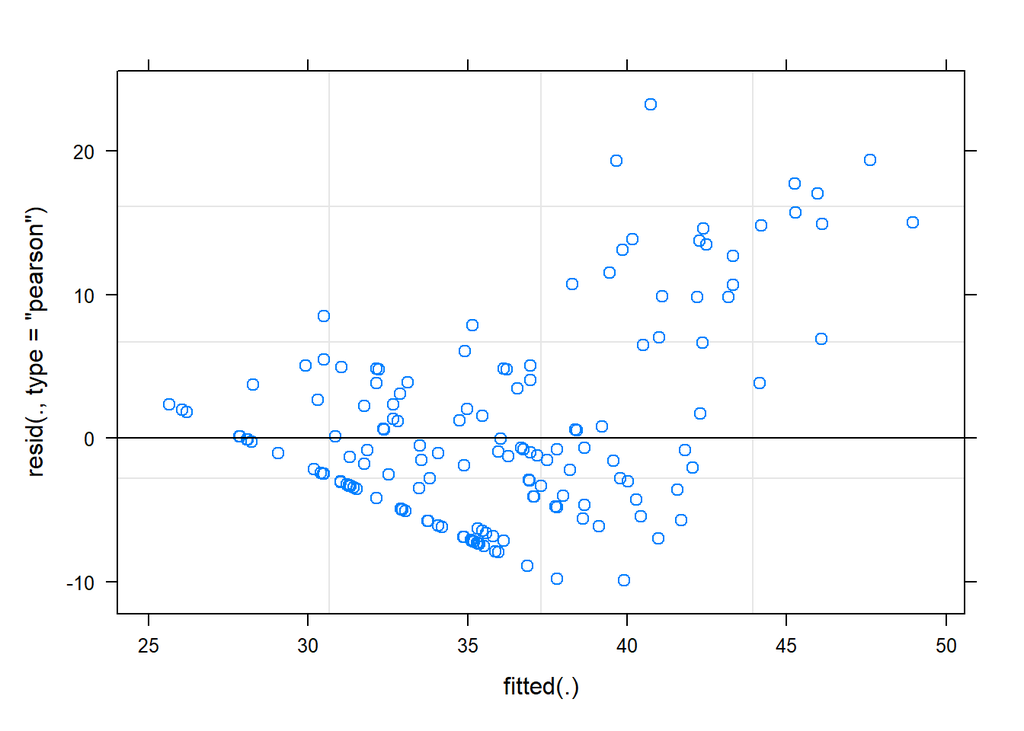

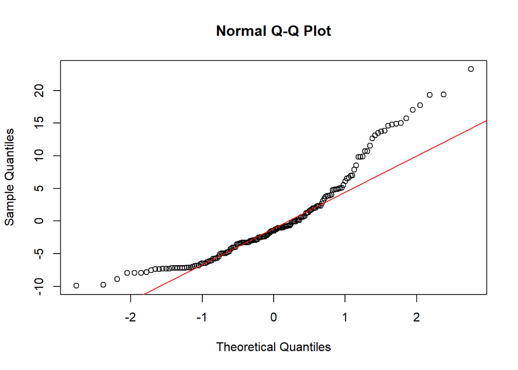

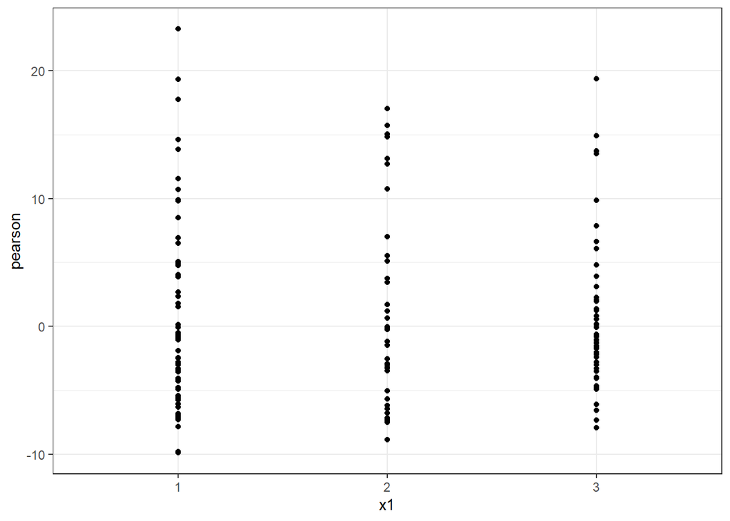

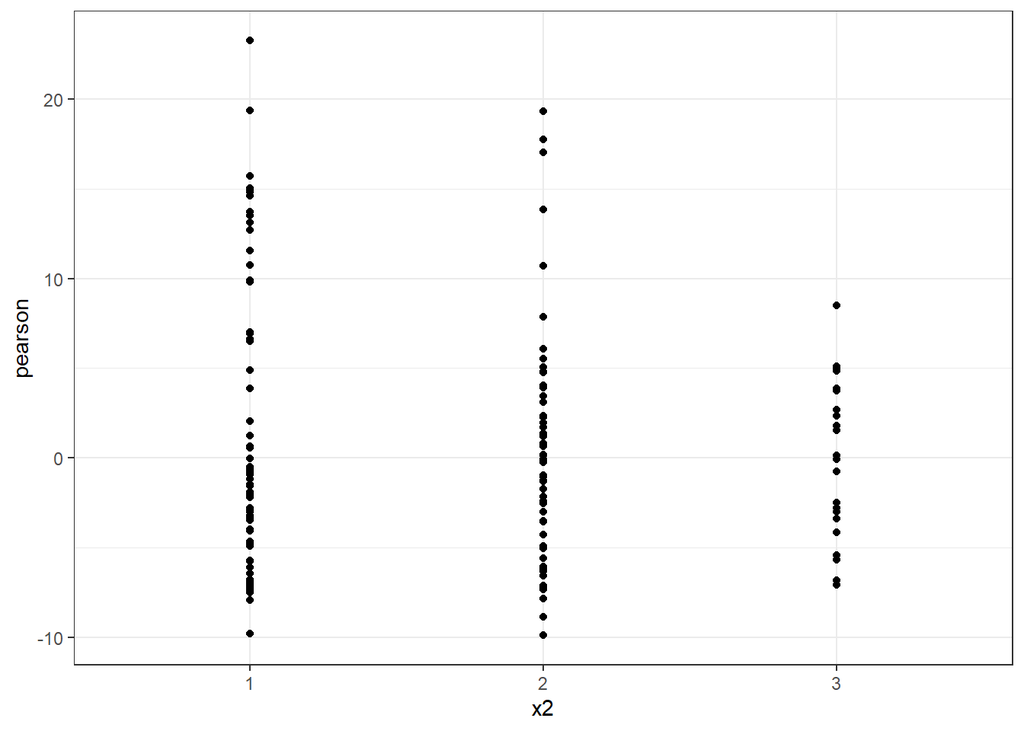

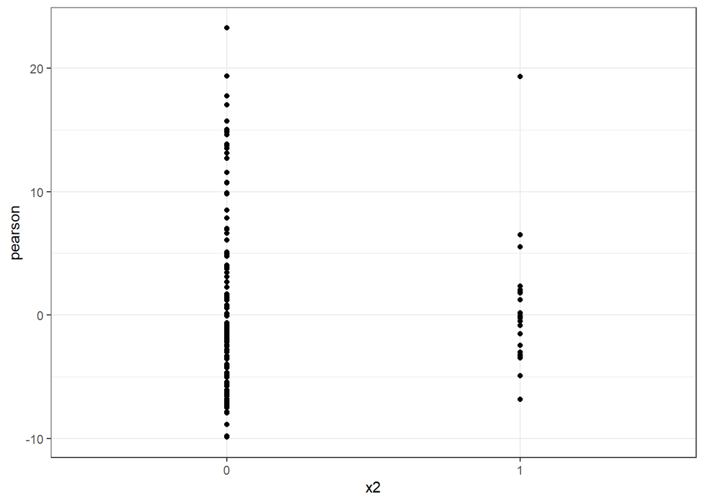

```r
rm(list = ls())
```